# METRICS2.1-V2-exp5

## Design : ibex Platform: sky130hd, asap7

A sample dataset with multiple runs varying the core utilization for the floorplan and the place density for global placement for the ibex_core design on sky130hd and asap7 platforms. All design metrics from the runs are collected for analysis.

Metrics data is represented as json files in the METRICS2.1 V2 format. Each experiment in the run is a separate json file. All of the files are read into a DataFrame 'json_df'.

- Rows of the DataFrame represent an experiment.
- Columns of the DataFrame represent the metrics.

```
Number of runs in the dataset: 4590
Number of metrics in each data: 114
```

- The columns in the DataFrame, which are the metrics colleced for each run.

```
Index(['run.flow__generate_date', 'run.flow__metrics_version',
       'run.flow__openroad_version', 'run.flow__openroad_commit',
       'run.flow__scripts_commit', 'run.flow__uuid', 'run.flow__design',
       'run.flow__platform', 'run.flow__platform_commit', 'run.flow__variant',
       ...
       'finish.timing__drv__max_cap', 'finish.power__internal__total',
       'finish.power__switchng__total', 'finish.power__leakage__total',
       'finish.power__total', 'finish.design__instance__area',
       'finish.design__instance__utilization', 'finish.runtime__total',
       'finish.cpu__total', 'finish.mem__peak'],
      dtype='object', length=114)
```

**Data Engineering**

- Extract only the relevant columns -- for this exercise, get the design name, platform, flow variant and route metrics including runtime and memory footprints.
- Parse the variant string and extract the relevant features -- Core Utilization and Place Density
- Rename columns to more meaningful names.
- Create new columns (features) based on other column values -- for e.g. Success/Fail for the global and detailed router.
- Print the head of the data frame. As we can see, all of the parameter values used in the experiment is in the "Variant" string. We will have to parse the string and create individual columns for the features we are interested in. For this experiment the only values changing for each run is the Core Utilization and the Place Density delta. So we extract those and store as column entries in the data frame. The Place Density delta is the incremental amount in the placement density for global placement above the lower bound value, which is a function of the Core Utilization.
- If the actual Place Densiy (lower bound value + delta) is greater than 1.0, the OpenROAD flow scripts sets the value at 1.0 for global placement.

|  | Design | Platform | Variant | GR WNS | Wire Length | Vias | DRC Errors | Route Runtime | Peak Mem |
| --- | --- | --- | --- | --- | --- | --- | --- | --- | --- |
| 0 | ibex | sky130hd | UTIL_14-AR_1.0-GAP_10-PD_LB_ADD_0.74-GR_OVERFLOW_0 | N/A | ERR | ERR | ERR | ERR | ERR |
| 0 | ibex | sky130hd | UTIL_42-AR_1.0-GAP_10-PD_LB_ADD_0.3-GR_OVERFLOW_0 | ERR | ERR | ERR | ERR | ERR | ERR |
| 0 | ibex | asap7 | UTIL_22-AR_1.0-GAP_10-PD_LB_ADD_0.66-GR_OVERFLOW_0 | 53.29 | 114760 | 217025 | ERR | 3:16:42 | 2.39554e+07 |
| 0 | ibex | asap7 | UTIL_32-AR_1.0-GAP_10-PD_LB_ADD_0.22-GR_OVERFLOW_0 | 0.4 | 118680 | 203071 | 0 | 14:53.53 | 7.1533e+06 |
| 0 | ibex | asap7 | UTIL_23-AR_1.0-GAP_10-PD_LB_ADD_0.48-GR_OVERFLOW_0 | 82.95 | 120883 | 205450 | 0 | 16:35.78 | 7.67539e+06 |

- Create new columns for whether the global router and detailed router completed successfully.

```
(2, 3)
Success  Platform  False  True
0        asap7     1090   1205
1        sky130hd  1832   463
```

```
Index(['Platform', False, True], dtype='object', name='Success')
```

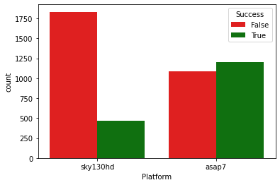

- We can see from the above plot that asap7 platform had a lot more successful runs than sky130hd.
- Lets examine the number of false positives by the Global router, i.e. global router completes but detailed router fails

```
asap7    1031
Name: Platform, dtype: int64
```

- As we can see from the above data all of the false positives are in asap7. This will happen if the layer adjust settings for the global router are too optimistic.
- Extract individual features from the "Variant" string. For this experiment we are interested in only the Core Utilization and the Place density delta
- Print the head of the dataframe after extracting the features and performing further data engineering. This data frame is now ready to be used. Notice that we have also created additional columns for capturing whether Global Route and Detailed Route completed.

|  | Design | Platform | Variant | GR WNS | Wire Length | Vias | DRC Errors | Route Runtime | Peak Mem | GR Success | Success | Core Util | Aspect Ratio | GAP | Place Density | GR_OVERFLOW |
| --- | --- | --- | --- | --- | --- | --- | --- | --- | --- | --- | --- | --- | --- | --- | --- | --- |
| 0 | ibex | sky130hd | UTIL_14-AR_1.0-GAP_10-PD_LB_ADD_0.74-GR_OVERFLOW_0 | N/A | ERR | ERR | ERR | ERR | ERR | False | False | 14.0 | 1.0 | 10.0 | 0.74 | 0.0 |
| 0 | ibex | sky130hd | UTIL_42-AR_1.0-GAP_10-PD_LB_ADD_0.3-GR_OVERFLOW_0 | ERR | ERR | ERR | ERR | ERR | ERR | False | False | 42.0 | 1.0 | 10.0 | 0.30 | 0.0 |
| 0 | ibex | asap7 | UTIL_22-AR_1.0-GAP_10-PD_LB_ADD_0.66-GR_OVERFLOW_0 | 53.29 | 114760 | 217025 | ERR | 3:16:42 | 2.39554e+07 | True | False | 22.0 | 1.0 | 10.0 | 0.66 | 0.0 |
| 0 | ibex | asap7 | UTIL_32-AR_1.0-GAP_10-PD_LB_ADD_0.22-GR_OVERFLOW_0 | 0.4 | 118680 | 203071 | 0 | 14:53.53 | 7.1533e+06 | True | True | 32.0 | 1.0 | 10.0 | 0.22 | 0.0 |
| 0 | ibex | asap7 | UTIL_23-AR_1.0-GAP_10-PD_LB_ADD_0.48-GR_OVERFLOW_0 | 82.95 | 120883 | 205450 | 0 | 16:35.78 | 7.67539e+06 | True | True | 23.0 | 1.0 | 10.0 | 0.48 | 0.0 |

[output not shown]

- Draw a scatter plots for the successful runs. The red trace is the max achived placement density (core utilization + place density delta). As we can see, in both platforms as the core utilization increases, the maximum achievable placement density decreases

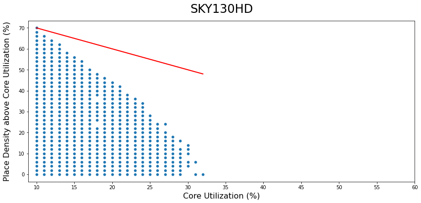

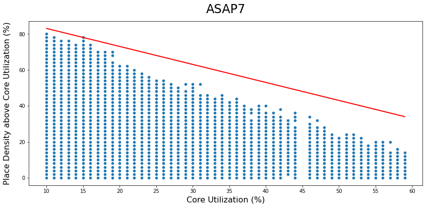

- Let us examine the scatter plot of success/failures for the two platforms.

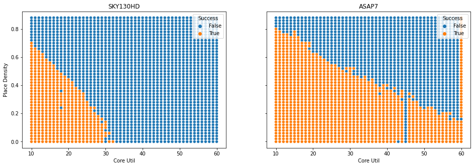

[output not shown]

[output cut: 100 more lines]

[output not shown]